# Linear Regression With Spline Term Application

Mathias Mathieu

30/06/2017

## Introduction

- A simple linear regression model fits a straight line to the data points
- By adding a spline term we can fit a linear model with a breakpoint
- We now have two straight lines that come together continously in the breakpoint
- This gives us a better fit, but beware of overfitting!
- What if we could interactively play around with the breakpoint on different data sets?
- [Our application](http://mercret.shinyapps.io/SplineRegression) gives this opportunity

## Example

We fit a simple linear model on the mtcars dataset, and a model with the spline term. We plot the data and the models. We also give the root mean squared error (RMSE) to indicate how well the models are fitted.  
This can all be done interactively in our application.

```r
model1 <- lm(hp~mpg,data=mtcars)
breakpoint <- 24
mtcars$spline  <- ifelse(mtcars$mpg - breakpoint > 0, mtcars$mpg - breakpoint, 0)
model2 <- lm(hp~mpg+spline,data=mtcars)

plot(mtcars$mpg,mtcars$hp,xlab="mpg",ylab="hp")
abline(model1,col="blue",lwd=2)
r <- range(mtcars$mpg)
s <- seq(r[1],r[2],length.out=100)
newdata=data.frame(mpg=s,spline=ifelse(s - breakpoint > 0, s - breakpoint,0))
modlines <- predict(model2,newdata)
lines(s,modlines,col="red",lwd=2)

print(paste("RMSE Linear Model:",sqrt(mean(model1$residuals^2))))
print(paste("RMSE Linear Model with Spline Term:",sqrt(mean(model2$residuals^2))))
```

## Example

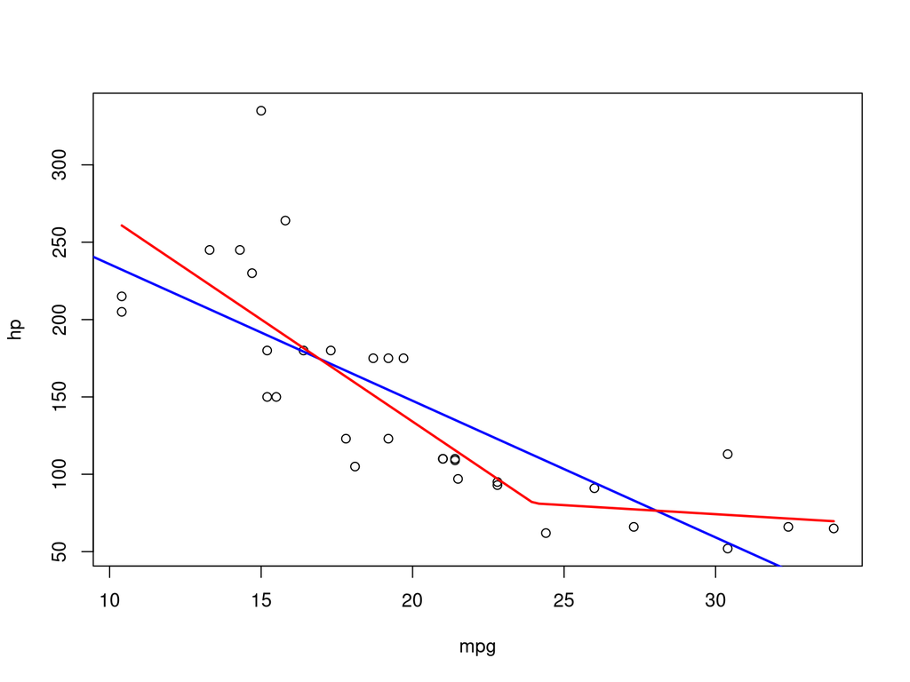

```
## [1] "RMSE Linear Model: 42.549810461895"
```

```
## [1] "RMSE Linear Model with Spline Term: 38.388077648804"
```

## The Application

- In the application you can choose from 4 different data sets provided by R (Old Faithful, Trees, Mtcars and Swiss)
- You can choose which variables are displayed on the plot, and fitted into a model
- The breakpoint of the regression with a spline term can be chosen interactively with a slider
- The root mean squared error of the two models is displayed, to give an indication of the improvement from using a breakpoint
- Have fun experimenting!